# Module One Discussion: Descriptive Statistics and Plots

This notebook will take you step-by-step through the calculations required for your Module One discussion post. It is very important to run through the steps in order. Some steps depend on the outputs of earlier steps. Once you have completed the steps in this notebook, be sure to answer the questions about this activity in the discussion for this module.

Reminder: If you have not already reviewed the discussion prompt, please do so before beginning this activity. That will give you an idea of the questions you will need to answer with the outputs of this script.

## Initial post (due Thursday)

### Step 1: Preparing the dataset

This block of Python code will generate the sample data in a Python dataframe that will be used in the calculations later. Your task is to use a website to collect the daily maximum temperature data for your city or zip code for the past fourteen days. Then, input your data in the code below by filling in the Python list. After entering your data in the Python list, click the code section below and hit the **Run** button above.

```python
# This module will be used to prepare a pandas dataframe and calculate descriptive statistics
import pandas as pd
import matplotlib.pyplot as plt
import seaborn as sns
import numpy as np
import random
```

```python
# using url of website for Healy, Alaska
# could not find historical data, only forecasted data
url = 'https://www.timeanddate.com/weather/@5863850/ext'

# read in all available HTML tables on the webpage
# Returns a list of df, even if only one table exists
tables = pd.read_html(url)

# output how many tables are found for content verification
print(f'Total tables found: {len(tables)} \n')

# only one table available, use first table found
df = tables[0]

# EDA
#print(df.head().to_string(index = False))
print(df.columns.to_list())
```

[output not shown]

```python
# prepare a dataframe for temperatures.
# Placing Day and Temperature into temperatures df
temperatures_df = df[[('Unnamed: 0_level_0', 'Day'), ('Conditions', 'Temperature')]]
temperatures_df.columns = ['Day', 'Temperature']

# Removing extra values not related to temp or day
temperatures_df = temperatures_df[~temperatures_df['Temperature'].str.contains("Updated", na = False)]

# Split high and Low Temps into individual columns
# use regex to capture numeric high and low temps from current formatting
temperatures_df[['High °F', 'Low °F']] = temperatures_df['Temperature'].str.extract(r'(\d+)\s*/\s*(\d+)')

# convert extracted temps from str to int for numerical analysis
temperatures_df['High °F'] = temperatures_df['High °F'].astype(int)
temperatures_df['Low °F'] = temperatures_df['Low °F'].astype(int)

# drop the temperatures column, no longer needed for analysis
temperatures_df.drop(columns = 'Temperature', inplace = True)

# print temperatures dataframe
print("2 Week Extended forecast for Healy, Alaska:\n\n", temperatures_df[['Day', 'High °F']].to_string(index = False))
```

```
2 Week Extended forecast for Healy, Alaska:

        Day  High °F
  TueJul 1       79
  WedJul 2       79
  ThuJul 3       83
  FriJul 4       86
  SatJul 5       86
  SunJul 6       80
  MonJul 7       81
  TueJul 8       73
  WedJul 9       70
 ThuJul 10       70
 FriJul 11       71
 SatJul 12       72
 SunJul 13       63
 MonJul 14       63
 TueJul 15       64
```

### Step 2: Calculating descriptive statistics

The block of code below will calculate descriptive statistics for the data set you entered. The pandas dataframe has several methods that calculate descriptive statistics. Each method has a comment telling you what that method calculates.

Click the code section below and hit the **Run** button above.

```python
# Pandas dataframe has several methods that calculate descriptive statistics.
# Creating a method to print metrics: Pass in the df and column to evaluate
def calc_metrics(df, column):
    mean = df[column].mean() # mean
    median = df[column].median() # median
    variance = df[column].var() # variance
    std_dev = df[column].std() # standard deviation
    describe = df[column].describe() # describe

    # Print metrics to console
    print(f'Metrics: Mean, Median, Variance, Std Deviation, & Describe \n')
    print (f'Mean: {mean:.2f} | Median: {median:.2f} | Variance: {variance:.2f} | Std Deviation: {std_dev:.2f}\n')
    print (f'Describe:\n{describe}')

# Print metrics for temperatuures_df using above method
print(calc_metrics(temperatures_df, 'High °F'))
```

```
Metrics: Mean, Median, Variance, Std Deviation, & Describe

Mean: 74.67 | Median: 73.00 | Variance: 63.24 | Std Deviation: 7.95

Describe:
count    15.000000
mean     74.666667
std       7.952238
min      63.000000
25%      70.000000
50%      73.000000
75%      80.500000
max      86.000000
Name: High °F, dtype: float64
None
```

### Step 3: Line graph to display trend

The block of code below will create a line plot of temperature data. You will use the matplotlib.pyplot submodule to create the line chart.

Click the code section below and hit the **Run** button above.  
NOTE: If the graph is not created, click the code section and hit the **Run** button again.

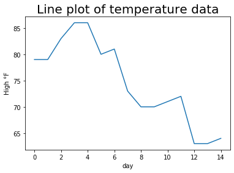

```python
# line chart
plt.plot(temperatures_df['High °F']) # plot

# setting a title for the plot, x-axis and y-axis
plt.title('Line plot of temperature data', fontsize=20)
plt.xlabel('day')
plt.ylabel('High °F')

# show the plot
plt.show()
```

### Step 4: Side-by-side boxplots to compare distributions

The block of code below will create side-by-side boxplots of your temperature data and the temperature data from another location called "Zion". Boxplots can be used to visually compare data distributions. In this code block, you will use the seaborn module in Python to create a side-by-side boxplot.

The temperature data for Zion will be generated automatically in the code section below. You are not required to know how this data was generated. Note that the temperature data for Zion will be unique to you.

Click the code section below and hit the **Run** button above.  
NOTE: If the graph is not created, click the code section and hit the **Run** button again.

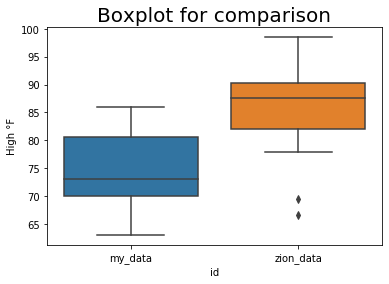

```python
# creates temperature data for Zion. You don't need to know how this data is created.
# The temperature data created for Zion will be unique to you.
mean = random.randint(temperatures_df['High °F'].min(),temperatures_df['High °F'].max())
std_deviation = random.randint(round(temperatures_df['High °F'].std(),0),round(2*temperatures_df['High °F'].std(),0))
zion_temperatures = np.random.normal(mean, std_deviation, 25)
zion_temperatures = pd.DataFrame(zion_temperatures, columns=['High °F'])

# side-by-side boxplots require the two dataframes to be concatenated and require a variable identifying the data
temperatures_df['id'] = 'my_data'
zion_temperatures['id'] = 'zion_data'
both_temp_df = pd.concat((temperatures_df, zion_temperatures), sort = False) # 'sort = False' to resolve error outputs

# sets a title for the plot, x-axis, and y-axis
plt.title('Boxplot for comparison', fontsize=20)

# prepares the boxplot
sns.boxplot(x="id",y="High °F",data=both_temp_df)

# shows the plot
plt.show()
```

## End of initial post

Attach the html output to your initial post in the Module One discussion. The HTML output can be downloaded by clicking **File**, then **Download as**, then **HTML**. Be sure to answer all questions about this activity in the Module One discussion.

## Follow-up posts (due Sunday)

Return to the Module One discussion to answer the follow-up questions in your response posts to other students. There are no Python scripts to run for your follow-up posts.